# Other processings

Other signal processing methods are available in `StructuralVibration.jl`.

## 1 Detrending

Detrending is the process of removing trends from a signal. This is useful when you want to analyze the fluctuations around a trend. The `detrend` function can be used to remove linear or polynomial trends from a signal.

### 1.1 API

**detrend**

```
detrend(t, y, order = 1, bp = [])
```

Detrend a signal `y` with respect to time `t` using a polynomial of order `order`.

**Inputs**

- `t`: Time vector

- `y`: Signal to be detrended

- `order`: Order of the polynomial (default is 1)

- `bp`: Breakpoints for the polynomial (default is empty)

**Output**

- `y_detrended`: Detrended signal

**Notes**

`order` can be a vector if the trend is different over the segments defined by the breakpoints `bp`.

The breakpoints `bp` are the points where the polynomial order changes. If `bp` is empty, a single polynomial is fitted to the entire signal.

### 1.2 Example

```julia
# Signal 1
x1 = -0.5:0.01:0.5
y1 = @. sin(π*x1) + 0.25
y1_const = detrend(x1, y1, 0)
y1_lin = detrend(x1, y1, 1)

# Signal 2
x2 = 0:0.1:20
y2 = @. 3sin(x2) + x2
y2_const = detrend(x2, y2, 0)
y2_lin = detrend(x2, y2, 1)
```

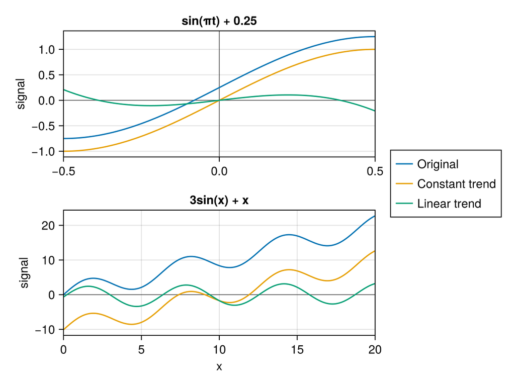

## 2 Gradient

### 2.1 API

**gradient**

```
gradient(f::Vector{Real}, t; method = :cubic)
gradient(f::Matrix{Real}, t; method = :cubic, dims = 1)
```

Compute the gradient of a function `f` at points `t`.

**Inputs**

- `f`: Function values

- `t`: Points at which to evaluate the gradient

- `method`: Interpolation method

  - `:linear`: Linear interpolation

  - `:cubic`: Cubic spline interpolation (default)

- `dims`: Dimension along which to compute the gradient

  - `1`: Rows (default)

  - `2`: Columns

**Output**

- `df`: Gradient of the vector `f` at points `t`

**Note**

If `method` is `:cubic`, `t` must be an `AbstractRange`.

### 2.2 Example

```julia
# Signal
x = LinRange(0., 3π, 100)
y = sin.(x)

# True gradient
dy = cos.(x)

# Estimated gradient
dy_approx = gradient(y, x)
```

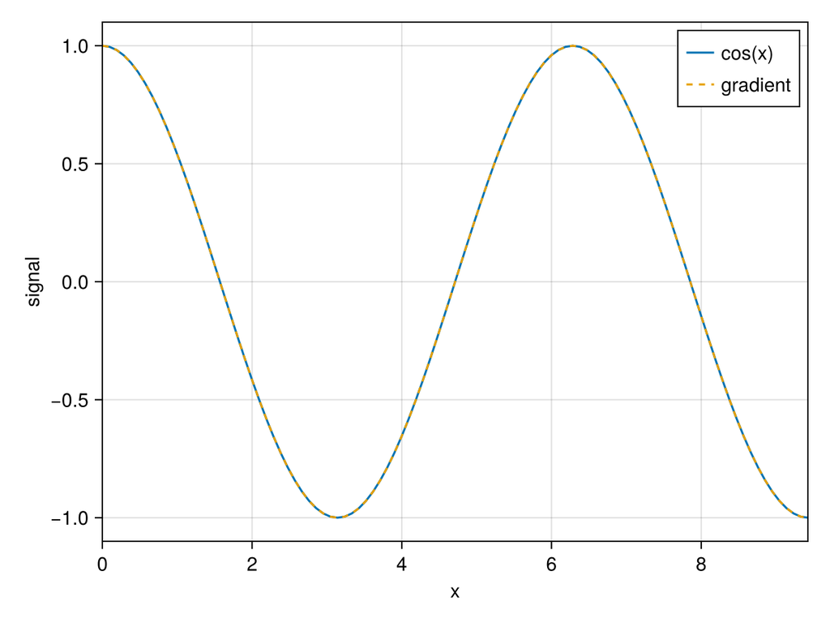

**Note**

Being based on interpolation, `gradient` is not robust against noise. For robust gradient estimation, you can compute the gradient of the signal denoised by the `denoising` function by using one of the numerous Julia differentiation packages if the signal is smooth enough (at least class $C^\2$). If the latter condition is not satisfied, you can for instance use [NoiseRobustDifferentiation.jl](https://adrianhill.de/NoiseRobustDifferentiation.jl/stable/), which implements the Total variation regularized numerical differentiation method[^1] .

## 3 Amplitude of a signal

In vibration measurements, the amplitude of a signal $x(t)$ (displacement, velocity or acceleration) can be defined in different ways:

- **Peak value**: $x_{peak} = \max(|x(t)|)$. It is often used for short-duration phenomena (e.g. shocks), but does not account for the time evolution of the vibration.
- **Peak-to-peak value**: $x_{p-p} = \max(x(t)) - \min(x(t))$. It is often used for displacement measurements, to be compared with a critical displacement.
- **Root mean square (RMS) value**:
  $$x_{RMS} = \sqrt{\frac{1}{T}\int_0^T x^2(t)\, dt}$$
  It is related to the vibratory energy and accounts for the time evolution of the signal.

### 3.1 API

**peak_value**

```
peak_value(x; dims = :)
```

Compute the peak value of a signal `x`.

The peak value is defined as:

x_peak = max(|x(t)|)

**Inputs**

- `x`: Signal (displacement, velocity, acceleration, ...)

- `dims`: Dimension along which the peak value is computed (default: all dimensions)

**Output**

- `x_peak`: Peak value

**Note**

The peak value is often used to characterize short-duration phenomena (e.g. shocks), but it does not account for the time evolution of the vibration.

**peak2peak**

```
peak2peak(x; dims = :)
```

Compute the peak-to-peak value of a signal `x`.

The peak-to-peak value is defined as:

x_pp = max(x(t)) - min(x(t))

**Inputs**

- `x`: Real signal (displacement, velocity, acceleration, ...)

- `dims`: Dimension along which the peak-to-peak value is computed (default: all dimensions)

**Output**

- `x_pp`: Peak-to-peak value

**Note**

The peak-to-peak value is often used for displacement measurements, to be compared with a critical displacement.

**Example**

```
julia> peak2peak([1., -3., 2.])
5.0
```

**rms_value**

```
rms_value(x; dims = :)
```

Compute the root mean square (RMS) value of a signal `x`.

The RMS value is defined as:

x_RMS = sqrt((1/T)∫₀ᵀ x²(t) dt)

For a sampled signal, it is computed as:

x_RMS = sqrt((1/N)∑ₙ |xₙ|²)

**Inputs**

- `x`: Signal (displacement, velocity, acceleration, ...)

- `dims`: Dimension along which the RMS value is computed (default: all dimensions)

**Output**

- `x_rms`: RMS value

### 3.2 Example

```julia
# Signal
fs = 1000
t = (0:fs - 1)/fs
x = @. 2sin(2π*5t) + 0.5

# Amplitudes
x_peak = peak_value(x)
x_pp = peak2peak(x)
x_rms = rms_value(x)

x_peak, x_pp, x_rms
```

[output not shown]

## 4 Phase unwrapping

The phase of a complex signal (FRF, spectrum, …) computed with `angle` is wrapped in the interval $(-\pi, \pi]$, which leads to artificial jumps of $2\pi$. The `unwrap_phase` function removes these jumps to obtain a continuous phase.

**Warning**

The unwrapping must always be performed in radians. Converting the phase to degrees **before** unwrapping it leads to wrong results. To get the unwrapped phase in degrees, use the `deg = true` keyword argument.

### 4.1 API

**unwrap_phase**

```
unwrap_phase(x; dims = 1, deg = false)
```

Compute the unwrapped phase of a signal `x`.

The phase returned by `angle` is wrapped in the interval (-π, π]. This function removes the artificial 2π jumps to obtain a continuous phase.

**Inputs**

- `x`: Signal

  - Complex signal (e.g. FRF, spectrum): the phase is first computed with `angle`

  - Real signal: `x` is assumed to be a wrapped phase expressed in **radians**

- `dims`: Dimension along which the phase is unwrapped (default: 1, i.e. each column is considered as a channel)

- `deg`: If `true`, the unwrapped phase is returned in degrees (default: `false`)

**Output**

- `ϕ`: Unwrapped phase [rad or deg]

**Notes**

Common pitfalls avoided by this function:

- The unwrapping is always performed in radians. Converting the phase to degrees **before** unwrapping it with a 2π range leads to wrong results.

- For multichannel signals, the unwrapping is performed independently along `dims`, so that the channels are not mixed.

The unwrapping relies on the assumption that the phase difference between two successive samples is lower than π. If the frequency resolution is too coarse, the unwrapped phase may be wrong.

**Example**

```
julia> freq = 0:0.1:1;

julia> H = exp.(-im*10freq);

julia> unwrap_phase(H)[end]
-10.0
```

### 4.2 Example

```julia
# FRF of a delayed system
freq = 0:0.5:100
τ = 0.02
H = @. exp(-2im*π*freq*τ)

# Wrapped and unwrapped phases
ϕ_wrapped = rad2deg.(angle.(H))
ϕ_unwrapped = unwrap_phase(H, deg = true)
```

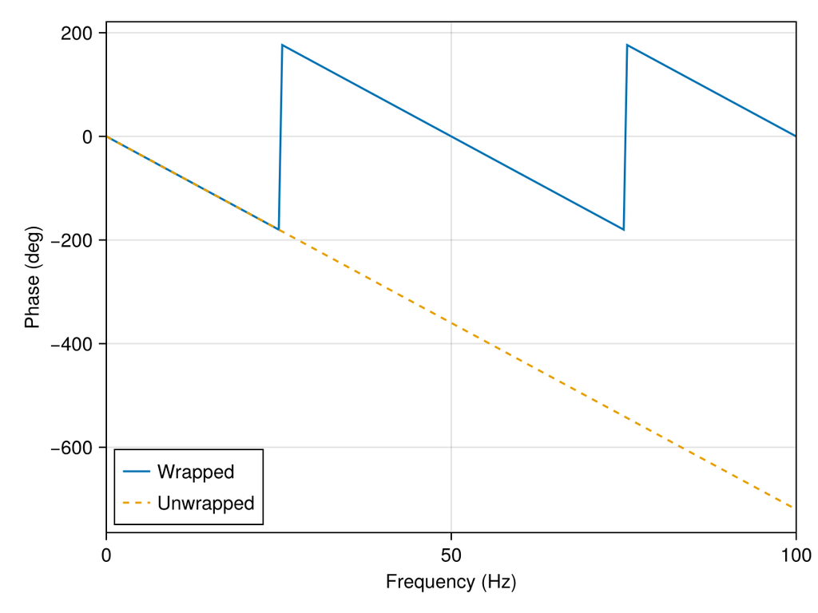

## 5 Decibel conversion

The `to_dB` function converts a signal to decibels with respect to a reference value. Two cases must be distinguished:

- **Amplitude (root-power) quantities** (displacement, velocity, acceleration, pressure, FRF, RMS values, …):
  $$L = 20 \log_{10}\left(\frac{|X|}{X_{ref}}\right)$$
- **Power (energy) quantities** (squared amplitude, power, energy, PSD, autospectrum, …):
  $$L = 10 \log_{10}\left(\frac{|X|}{X_{ref}}\right)$$

In both cases, $X_{ref}$ is expressed in the same unit as $X$. For a power quantity, the reference is therefore the square of the amplitude reference, so that both definitions lead to the same level.

Usual reference values can be obtained with the `ref_dB` function.

### 5.1 API

**to_dB**

```
to_dB(x, ref = 1.; type = :amplitude)
```

Convert a signal `x` to decibels (dB) with respect to the reference value `ref`.

**Inputs**

- `x`: Signal to convert (scalar or array, real or complex)

- `ref`: Reference value, expressed in the same unit as `x` (default: 1.)

- `type`: Type of quantity contained in `x`

  - `:amplitude` (default): Root-power (field) quantity - displacement, velocity, acceleration, pressure, FRF, RMS values, ...

    L = 20 log₁₀(|x|/ref)

  - `:power`: Power (or energy) quantity - squared amplitude, power, energy, PSD, autospectrum, ...

    L = 10 log₁₀(|x|/ref)

**Output**

- `L`: Level of `x` in dB

**Notes**

Both definitions give the same level for a given physical quantity, provided that `ref` is consistent with `x`. For a power quantity, `ref` must therefore be a power reference, i.e. the square of the amplitude reference (e.g. `ref = (2e-5)^2` Pa² for a pressure autospectrum).

Usual reference values are given by `ref_dB`.

Null values of `x` give `-Inf` dB.

**ref_dB**

```
ref_dB(quantity::Symbol; type = :amplitude)
```

Return the usual reference value used to express a `quantity` in decibels (SI units).

**Inputs**

- `quantity`: Type of physical quantity

  - `:mobility`: 1 m/s/N

  - `:accelerance`: 1 m/s²/N

  - `:displacement`: 1 pm = 1e-12 m

  - `:velocity`: 1 nm/s = 1e-9 m/s

  - `:acceleration`: 1 µm/s² = 1e-6 m/s²

  - `:pressure`: 20 µPa = 2e-5 Pa

- `type`: Type of quantity to be converted (see `to_dB`)

  - `:amplitude` (default): Amplitude reference value

  - `:power`: Power reference value, i.e. the square of the amplitude reference value

**Output**

- `ref`: Reference value

[output not shown]

## Footnotes

[^1]: R. Chartrand. “Numerical differentiation of noisy, nonsmooth data”. ISRN Applied Mathematics, vol. 2011, 164564, 2011.